# 08_CORRELACAO_E_REGRESSAO

## Correlação e Coeficiente de Determinação

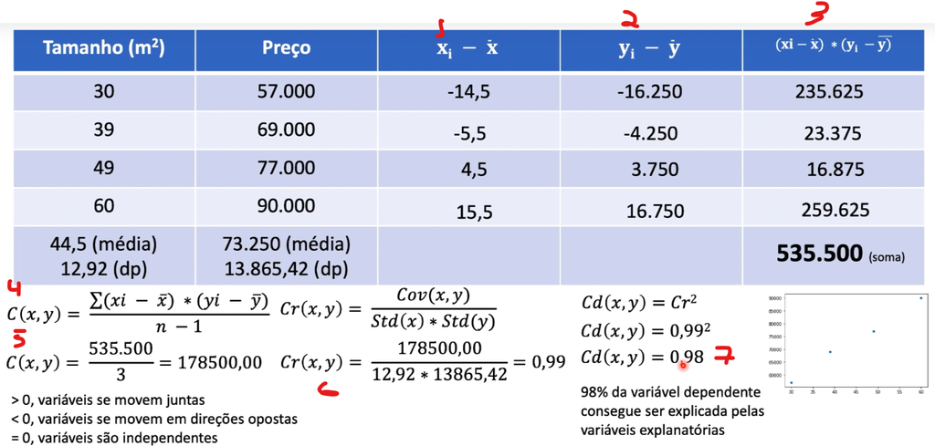

1° passo é descobrir a covariância (mede a variação com base no desvio padrão)

2° passo encontrar o coeficiente de correlação

3° passo encontrar o coeficiente de determinação

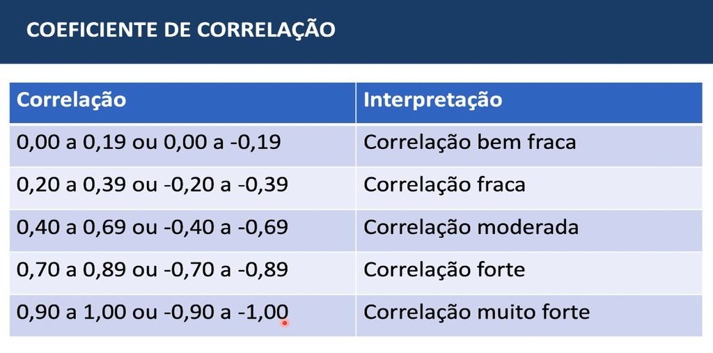

```python
import numpy as np
import pandas as pd
import seaborn as sns
import math
```

### Dados

```python
tamanho = np.array([30, 39, 49, 60])
preco = np.array([57000, 69000, 77000, 90000])
```

```python
dataset = pd.DataFrame({'tamanho': tamanho, 'preco': preco})
dataset
```

|  | tamanho | preco |
| --- | --- | --- |
| 0 | 30 | 57000 |
| 1 | 39 | 69000 |
| 2 | 49 | 77000 |
| 3 | 60 | 90000 |

```python
media_tamanho = dataset['tamanho'].mean()
media_preco = dataset['preco'].mean()
media_tamanho, media_preco
```

```
(44.5, 73250.0)
```

```python
dp_tamanho = dataset['tamanho'].std()
dp_preco = dataset['preco'].std()
dp_tamanho, dp_preco
```

```
(12.922847983320086, 13865.424623862047)
```

#### Calculo Manual

```python
dataset['dif'] = (dataset['tamanho'] - media_tamanho) * (dataset['preco'] - media_preco)
dataset
```

|  | tamanho | preco | dif |
| --- | --- | --- | --- |
| 0 | 30 | 57000 | 235625.0 |
| 1 | 39 | 69000 | 23375.0 |
| 2 | 49 | 77000 | 16875.0 |
| 3 | 60 | 90000 | 259625.0 |

```python
soma_dif = dataset['dif'].sum()
soma_dif
```

```
535500.0
```

```python
dataset['soma_dif']=soma_dif
```

```python
dataset['covariancia']=soma_dif/ (len(dataset)-1)
```

```python
dataset['coef_corr']=dataset['covariancia']/(dp_tamanho * dp_preco)
dataset['coef_det']=math.pow(dataset['coef_corr'][0],2) #pegar apenas um valor
dataset
```

|  | tamanho | preco | dif | soma_dif | covariancia | coef_corr | coef_det |
| --- | --- | --- | --- | --- | --- | --- | --- |
| 0 | 30 | 57000 | 235625.0 | 535500.0 | 178500.0 | 0.996201 | 0.992416 |
| 1 | 39 | 69000 | 23375.0 | 535500.0 | 178500.0 | 0.996201 | 0.992416 |
| 2 | 49 | 77000 | 16875.0 | 535500.0 | 178500.0 | 0.996201 | 0.992416 |
| 3 | 60 | 90000 | 259625.0 | 535500.0 | 178500.0 | 0.996201 | 0.992416 |

```python
dataset
```

|  | tamanho | preco | dif | soma_dif | covariancia | coef_corr | coef_det |
| --- | --- | --- | --- | --- | --- | --- | --- |
| 0 | 30 | 57000 | 235625.0 | 535500.0 | 178500.0 | 0.996201 | 0.992416 |
| 1 | 39 | 69000 | 23375.0 | 535500.0 | 178500.0 | 0.996201 | 0.992416 |
| 2 | 49 | 77000 | 16875.0 | 535500.0 | 178500.0 | 0.996201 | 0.992416 |
| 3 | 60 | 90000 | 259625.0 | 535500.0 | 178500.0 | 0.996201 | 0.992416 |

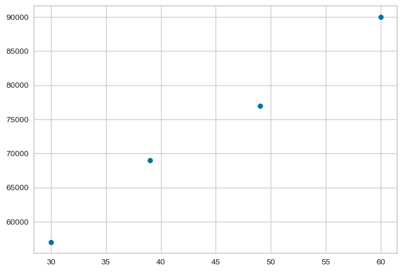

```python
sns.scatterplot(x=tamanho,y=preco)
```

#### Calculo Numpy e Pandas

```python
dataset[['tamanho','preco']].corr() # tira a correlacao entre as colunas
```

|  | tamanho | preco |
| --- | --- | --- |
| tamanho | 1.000000 | 0.996201 |
| preco | 0.996201 | 1.000000 |

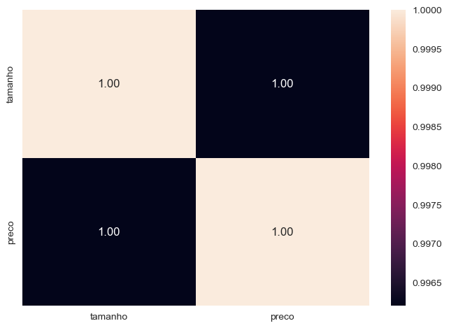

```python
sns.heatmap(dataset[['tamanho','preco']].corr() ,annot=True,fmt='.2f')
```

### Exercício - correlação base de dados preço das casas

```python
dataset = pd.read_csv('data_base/house_prices.csv')
dataset.head()
```

|  | id | date | price | bedrooms | bathrooms | sqft_living | sqft_lot | floors | waterfront | view | ... | grade | sqft_above | sqft_basement | yr_built | yr_renovated | zipcode | lat | long | sqft_living15 | sqft_lot15 |
| --- | --- | --- | --- | --- | --- | --- | --- | --- | --- | --- | --- | --- | --- | --- | --- | --- | --- | --- | --- | --- | --- |
| 0 | 7129300520 | 20141013T000000 | 221900.0 | 3 | 1.00 | 1180 | 5650 | 1.0 | 0 | 0 | ... | 7 | 1180 | 0 | 1955 | 0 | 98178 | 47.5112 | -122.257 | 1340 | 5650 |
| 1 | 6414100192 | 20141209T000000 | 538000.0 | 3 | 2.25 | 2570 | 7242 | 2.0 | 0 | 0 | ... | 7 | 2170 | 400 | 1951 | 1991 | 98125 | 47.7210 | -122.319 | 1690 | 7639 |
| 2 | 5631500400 | 20150225T000000 | 180000.0 | 2 | 1.00 | 770 | 10000 | 1.0 | 0 | 0 | ... | 6 | 770 | 0 | 1933 | 0 | 98028 | 47.7379 | -122.233 | 2720 | 8062 |
| 3 | 2487200875 | 20141209T000000 | 604000.0 | 4 | 3.00 | 1960 | 5000 | 1.0 | 0 | 0 | ... | 7 | 1050 | 910 | 1965 | 0 | 98136 | 47.5208 | -122.393 | 1360 | 5000 |
| 4 | 1954400510 | 20150218T000000 | 510000.0 | 3 | 2.00 | 1680 | 8080 | 1.0 | 0 | 0 | ... | 8 | 1680 | 0 | 1987 | 0 | 98074 | 47.6168 | -122.045 | 1800 | 7503 |

5 rows × 21 columns

```python
dataset.drop(labels = ['id', 'date', 'sqft_living', 'sqft_lot'], axis = 1, inplace=True)
dataset.head()
```

|  | price | bedrooms | bathrooms | floors | waterfront | view | condition | grade | sqft_above | sqft_basement | yr_built | yr_renovated | zipcode | lat | long | sqft_living15 | sqft_lot15 |
| --- | --- | --- | --- | --- | --- | --- | --- | --- | --- | --- | --- | --- | --- | --- | --- | --- | --- |
| 0 | 221900.0 | 3 | 1.00 | 1.0 | 0 | 0 | 3 | 7 | 1180 | 0 | 1955 | 0 | 98178 | 47.5112 | -122.257 | 1340 | 5650 |
| 1 | 538000.0 | 3 | 2.25 | 2.0 | 0 | 0 | 3 | 7 | 2170 | 400 | 1951 | 1991 | 98125 | 47.7210 | -122.319 | 1690 | 7639 |
| 2 | 180000.0 | 2 | 1.00 | 1.0 | 0 | 0 | 3 | 6 | 770 | 0 | 1933 | 0 | 98028 | 47.7379 | -122.233 | 2720 | 8062 |
| 3 | 604000.0 | 4 | 3.00 | 1.0 | 0 | 0 | 5 | 7 | 1050 | 910 | 1965 | 0 | 98136 | 47.5208 | -122.393 | 1360 | 5000 |
| 4 | 510000.0 | 3 | 2.00 | 1.0 | 0 | 0 | 3 | 8 | 1680 | 0 | 1987 | 0 | 98074 | 47.6168 | -122.045 | 1800 | 7503 |

```python
dataset.corr()
```

|  | price | bedrooms | bathrooms | floors | waterfront | view | condition | grade | sqft_above | sqft_basement | yr_built | yr_renovated | zipcode | lat | long | sqft_living15 | sqft_lot15 |
| --- | --- | --- | --- | --- | --- | --- | --- | --- | --- | --- | --- | --- | --- | --- | --- | --- | --- |
| price | 1.000000 | 0.308350 | 0.525138 | 0.256794 | 0.266369 | 0.397293 | 0.036362 | 0.667434 | 0.605567 | 0.323816 | 0.054012 | 0.126434 | -0.053203 | 0.307003 | 0.021626 | 0.585379 | 0.082447 |
| bedrooms | 0.308350 | 1.000000 | 0.515884 | 0.175429 | -0.006582 | 0.079532 | 0.028472 | 0.356967 | 0.477600 | 0.303093 | 0.154178 | 0.018841 | -0.152668 | -0.008931 | 0.129473 | 0.391638 | 0.029244 |
| bathrooms | 0.525138 | 0.515884 | 1.000000 | 0.500653 | 0.063744 | 0.187737 | -0.124982 | 0.664983 | 0.685342 | 0.283770 | 0.506019 | 0.050739 | -0.203866 | 0.024573 | 0.223042 | 0.568634 | 0.087175 |
| floors | 0.256794 | 0.175429 | 0.500653 | 1.000000 | 0.023698 | 0.029444 | -0.263768 | 0.458183 | 0.523885 | -0.245705 | 0.489319 | 0.006338 | -0.059121 | 0.049614 | 0.125419 | 0.279885 | -0.011269 |
| waterfront | 0.266369 | -0.006582 | 0.063744 | 0.023698 | 1.000000 | 0.401857 | 0.016653 | 0.082775 | 0.072075 | 0.080588 | -0.026161 | 0.092885 | 0.030285 | -0.014274 | -0.041910 | 0.086463 | 0.030703 |
| view | 0.397293 | 0.079532 | 0.187737 | 0.029444 | 0.401857 | 1.000000 | 0.045990 | 0.251321 | 0.167649 | 0.276947 | -0.053440 | 0.103917 | 0.084827 | 0.006157 | -0.078400 | 0.280439 | 0.072575 |
| condition | 0.036362 | 0.028472 | -0.124982 | -0.263768 | 0.016653 | 0.045990 | 1.000000 | -0.144674 | -0.158214 | 0.174105 | -0.361417 | -0.060618 | 0.003026 | -0.014941 | -0.106500 | -0.092824 | -0.003406 |
| grade | 0.667434 | 0.356967 | 0.664983 | 0.458183 | 0.082775 | 0.251321 | -0.144674 | 1.000000 | 0.755923 | 0.168392 | 0.446963 | 0.014414 | -0.184862 | 0.114084 | 0.198372 | 0.713202 | 0.119248 |
| sqft_above | 0.605567 | 0.477600 | 0.685342 | 0.523885 | 0.072075 | 0.167649 | -0.158214 | 0.755923 | 1.000000 | -0.051943 | 0.423898 | 0.023285 | -0.261190 | -0.000816 | 0.343803 | 0.731870 | 0.194050 |
| sqft_basement | 0.323816 | 0.303093 | 0.283770 | -0.245705 | 0.080588 | 0.276947 | 0.174105 | 0.168392 | -0.051943 | 1.000000 | -0.133124 | 0.071323 | 0.074845 | 0.110538 | -0.144765 | 0.200355 | 0.017276 |
| yr_built | 0.054012 | 0.154178 | 0.506019 | 0.489319 | -0.026161 | -0.053440 | -0.361417 | 0.446963 | 0.423898 | -0.133124 | 1.000000 | -0.224874 | -0.346869 | -0.148122 | 0.409356 | 0.326229 | 0.070958 |
| yr_renovated | 0.126434 | 0.018841 | 0.050739 | 0.006338 | 0.092885 | 0.103917 | -0.060618 | 0.014414 | 0.023285 | 0.071323 | -0.224874 | 1.000000 | 0.064357 | 0.029398 | -0.068372 | -0.002673 | 0.007854 |
| zipcode | -0.053203 | -0.152668 | -0.203866 | -0.059121 | 0.030285 | 0.084827 | 0.003026 | -0.184862 | -0.261190 | 0.074845 | -0.346869 | 0.064357 | 1.000000 | 0.267048 | -0.564072 | -0.279033 | -0.147221 |
| lat | 0.307003 | -0.008931 | 0.024573 | 0.049614 | -0.014274 | 0.006157 | -0.014941 | 0.114084 | -0.000816 | 0.110538 | -0.148122 | 0.029398 | 0.267048 | 1.000000 | -0.135512 | 0.048858 | -0.086419 |
| long | 0.021626 | 0.129473 | 0.223042 | 0.125419 | -0.041910 | -0.078400 | -0.106500 | 0.198372 | 0.343803 | -0.144765 | 0.409356 | -0.068372 | -0.564072 | -0.135512 | 1.000000 | 0.334605 | 0.254451 |
| sqft_living15 | 0.585379 | 0.391638 | 0.568634 | 0.279885 | 0.086463 | 0.280439 | -0.092824 | 0.713202 | 0.731870 | 0.200355 | 0.326229 | -0.002673 | -0.279033 | 0.048858 | 0.334605 | 1.000000 | 0.183192 |
| sqft_lot15 | 0.082447 | 0.029244 | 0.087175 | -0.011269 | 0.030703 | 0.072575 | -0.003406 | 0.119248 | 0.194050 | 0.017276 | 0.070958 | 0.007854 | -0.147221 | -0.086419 | 0.254451 | 0.183192 | 1.000000 |

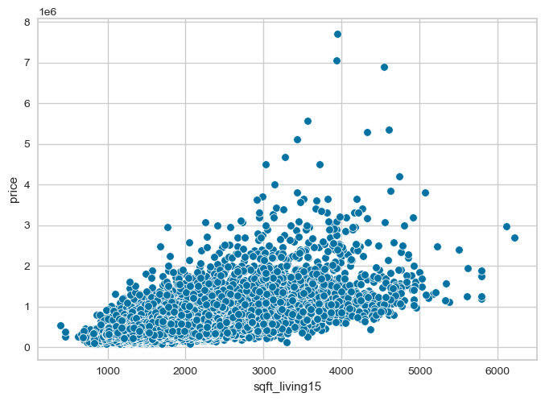

```python
sns.scatterplot(x=dataset['sqft_living15'], y=dataset['price']);
```

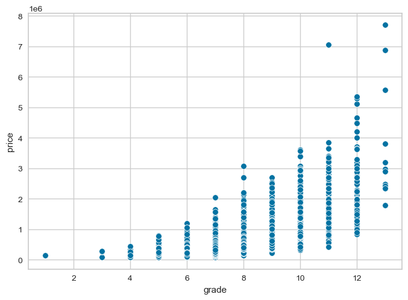

```python
sns.scatterplot(x=dataset['grade'], y=dataset['price']);
```

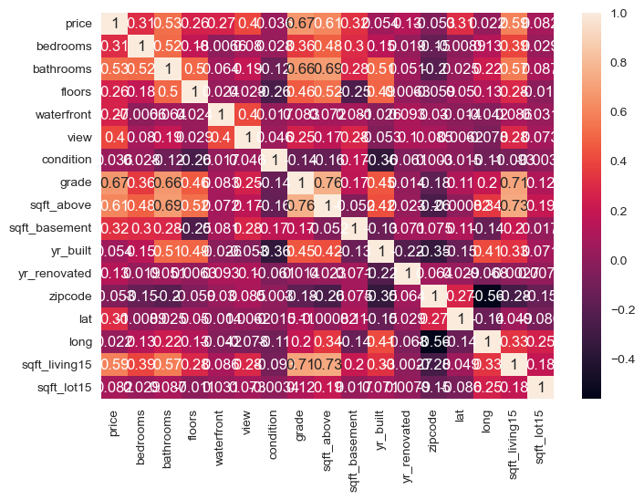

```python
sns.heatmap(dataset.corr(), annot=True);
```

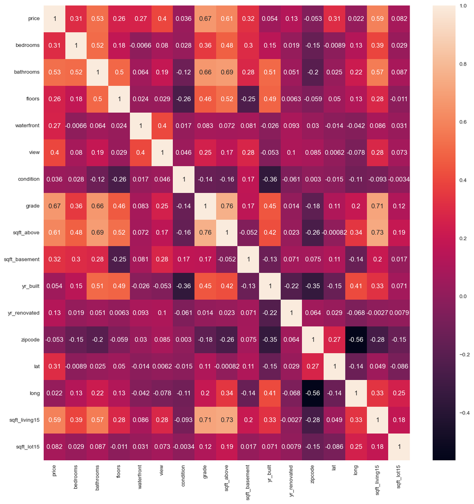

```python
import matplotlib.pyplot as plt
fig, ax = plt.subplots(figsize=(15,15))
ax = sns.heatmap(dataset.corr(), annot=True)
```

### Yellowbricks

[figure not shown]

```python
from yellowbrick.target import FeatureCorrelation
```

```python
!pip install yellowbrick --upgrade
```

```python
dataset.columns[1:]
```

```
Index(['bedrooms', 'bathrooms', 'floors', 'waterfront', 'view', 'condition',
       'grade', 'sqft_above', 'sqft_basement', 'yr_built', 'yr_renovated',
       'zipcode', 'lat', 'long', 'sqft_living15', 'sqft_lot15'],
      dtype='object')
```

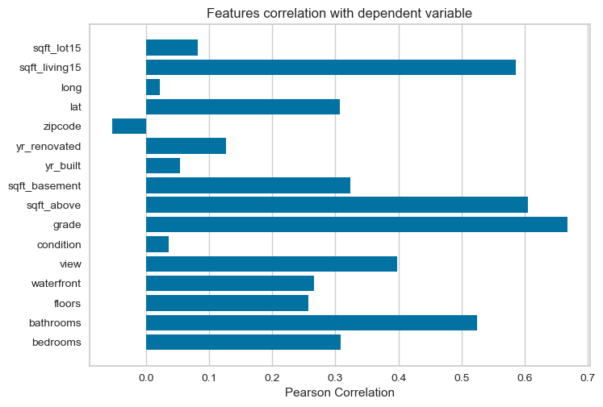

```python
grafico = FeatureCorrelation(labels = dataset.columns[1:])
grafico.fit(dataset.iloc[:, 1:].values, dataset.iloc[:, 0].values) # Cada atributo de X será averiguado com um atributo designado em Y para cálculo de correlação
grafico.show();
```

```python
dataset # no caso a cima estamos tentando ver a correlação com o preço
```

|  | price | bedrooms | bathrooms | floors | waterfront | view | condition | grade | sqft_above | sqft_basement | yr_built | yr_renovated | zipcode | lat | long | sqft_living15 | sqft_lot15 |
| --- | --- | --- | --- | --- | --- | --- | --- | --- | --- | --- | --- | --- | --- | --- | --- | --- | --- |
| 0 | 221900.0 | 3 | 1.00 | 1.0 | 0 | 0 | 3 | 7 | 1180 | 0 | 1955 | 0 | 98178 | 47.5112 | -122.257 | 1340 | 5650 |
| 1 | 538000.0 | 3 | 2.25 | 2.0 | 0 | 0 | 3 | 7 | 2170 | 400 | 1951 | 1991 | 98125 | 47.7210 | -122.319 | 1690 | 7639 |
| 2 | 180000.0 | 2 | 1.00 | 1.0 | 0 | 0 | 3 | 6 | 770 | 0 | 1933 | 0 | 98028 | 47.7379 | -122.233 | 2720 | 8062 |
| 3 | 604000.0 | 4 | 3.00 | 1.0 | 0 | 0 | 5 | 7 | 1050 | 910 | 1965 | 0 | 98136 | 47.5208 | -122.393 | 1360 | 5000 |
| 4 | 510000.0 | 3 | 2.00 | 1.0 | 0 | 0 | 3 | 8 | 1680 | 0 | 1987 | 0 | 98074 | 47.6168 | -122.045 | 1800 | 7503 |
| ... | ... | ... | ... | ... | ... | ... | ... | ... | ... | ... | ... | ... | ... | ... | ... | ... | ... |
| 21608 | 360000.0 | 3 | 2.50 | 3.0 | 0 | 0 | 3 | 8 | 1530 | 0 | 2009 | 0 | 98103 | 47.6993 | -122.346 | 1530 | 1509 |
| 21609 | 400000.0 | 4 | 2.50 | 2.0 | 0 | 0 | 3 | 8 | 2310 | 0 | 2014 | 0 | 98146 | 47.5107 | -122.362 | 1830 | 7200 |
| 21610 | 402101.0 | 2 | 0.75 | 2.0 | 0 | 0 | 3 | 7 | 1020 | 0 | 2009 | 0 | 98144 | 47.5944 | -122.299 | 1020 | 2007 |
| 21611 | 400000.0 | 3 | 2.50 | 2.0 | 0 | 0 | 3 | 8 | 1600 | 0 | 2004 | 0 | 98027 | 47.5345 | -122.069 | 1410 | 1287 |
| 21612 | 325000.0 | 2 | 0.75 | 2.0 | 0 | 0 | 3 | 7 | 1020 | 0 | 2008 | 0 | 98144 | 47.5941 | -122.299 | 1020 | 1357 |

21613 rows × 17 columns

## Regressão Linear Simples

A ideial aqui é criar um regressor (calcular um valor numérico), de modo a tentar traçar uma reta que ao jogarmos um valor de X, temos um y de qual seria o valor final.

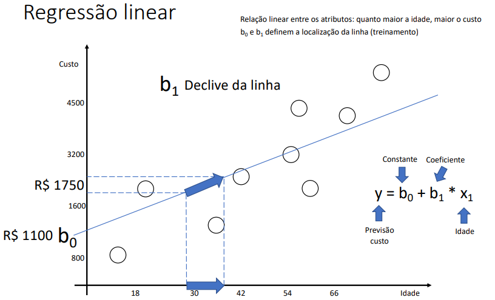

A correção para encontrar os valores de coeficiente da reta e o intercepto de y são com base no algoritmo de descida do gradiente.

O pseudo código abaixo vai mostrar a ideia:

Seja w os pesos da equação, b o parametro de bias, t o estado inicial do treinamento e η (eta) a taxa de aprendizado

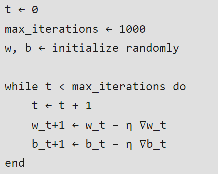

A cada iteração é decidido se o valor de correção de pesos será alto ou baixo de acordo com a distância do erro.

Tomando a equação y= ax +b

a= a - η * gradient(y) ==> derivada da função de custo em relação a m b= b - η * gradient(y) ==> derivada da função de custo em relação a b

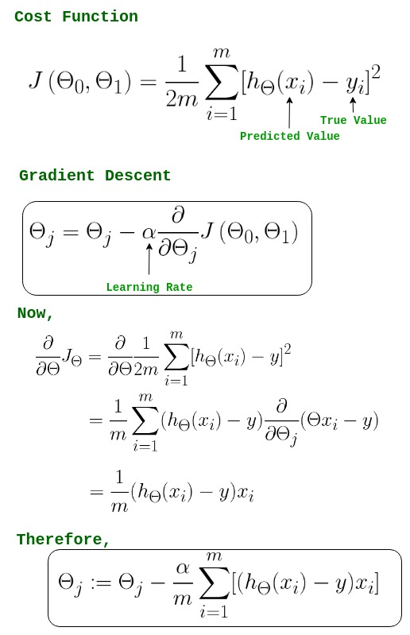

Lembrando a derivada em mínimos locais/globais tende a 0.

resumindo a história para o calculo do erro:

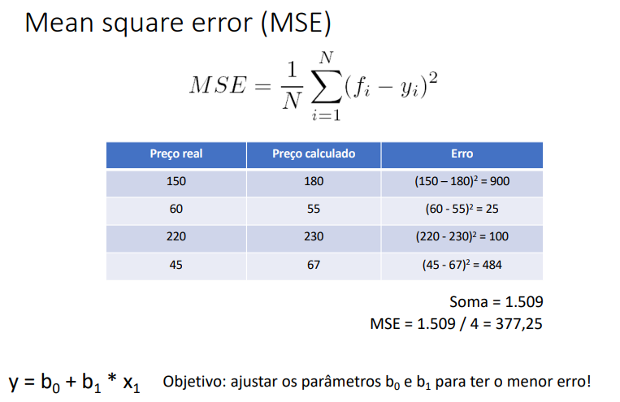

temos as seguintes derivadas :  
Derivada do custo em relação ao coeficiente a é igual a derivada do custo em relação ao erro x derivada do erro em relação ao coeficiente (regra da cadeia)

d(custo)/d(variavel a)= d(custo)/ d (erro) x d (erro)/d (a)

d(custo)/d(variavel a)= 2 x (erro) x d(erro)/d (a)  
= 2 x (a x (xi) + bi) x (xi) resultado da derivada

d(cust)/d(variavel b)= 2 x (erro) x d(erro)/d (b)  
= 2 x (a x (xi) + bi) x 1 (resultado da derivada da função em relação a b)

o mesmo é aplicado para a constante b, mas tratando ax como constante e ficando apenas b, que é 1

Com isso em mãos, temos a primeira iteração de treinamento:

a e b são gerados aleatoriamente, temos o xi do dataset entrando como valor em y=axi+b, com isso calculamos um y para seguir com o ajustes de a e b.

```python
X = dataset['sqft_living15'].values
X.shape
```

```
(21613,)
```

```python
X = X.reshape(-1, 1) #adiciona uma dimensao de coluna
X.shape
```

```
(21613, 1)
```

```python
y = dataset['price'].values
y
```

```
array([221900., 538000., 180000., ..., 402101., 400000., 325000.])
```

```python
from sklearn.model_selection import train_test_split
X_treinamento, X_teste, y_treinamento, y_teste = train_test_split(X, y, test_size = 0.2, random_state = 1)
X_treinamento.shape, X_teste.shape
```

```
((17290, 1), (4323, 1))
```

```python
from sklearn.linear_model import LinearRegression
regressor = LinearRegression()
regressor.fit(X_treinamento, y_treinamento)
```

```
LinearRegression()
```

```python
regressor.intercept_
```

```
-65779.26771579555
```

```python
regressor.coef_
```

```
array([304.24389402])
```

```python
regressor.intercept_ + regressor.coef_ * 900
```

```
array([208040.23690391])
```

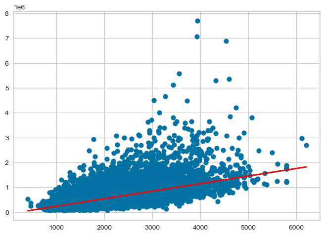

```python
import matplotlib.pyplot as plt
plt.scatter(X, y)
plt.plot(X, regressor.predict(X), color = 'red')
```

```python
regressor.score(X_treinamento, y_treinamento)
```

```
0.3432128000738559
```

```python
regressor.score(X_teste, y_teste)
```

```
0.3394744126244147
```

## Metricas de Erro

```python
previsoes = regressor.predict(X_teste)
```

```python
previsoes, y_teste
```

```
(array([ 816528.02494771,  427095.84059968, 1108602.16320873, ...,
         494029.4972845 , 1014286.55606194,  487944.61940406]),
 array([ 459000.,  445000., 1057000., ...,  260000., 1795000.,  418000.]))
```

```python
from sklearn.metrics import mean_absolute_error, mean_squared_error
```

```python
mean_absolute_error(y_teste, previsoes)
```

```
190622.04850436817
```

```python
mean_squared_error(y_teste, previsoes)
```

```
114007357796.49193
```

```python
math.sqrt(mean_squared_error(y_teste, previsoes))
```

```
337649.75610311335
```

## Regressão Multipla

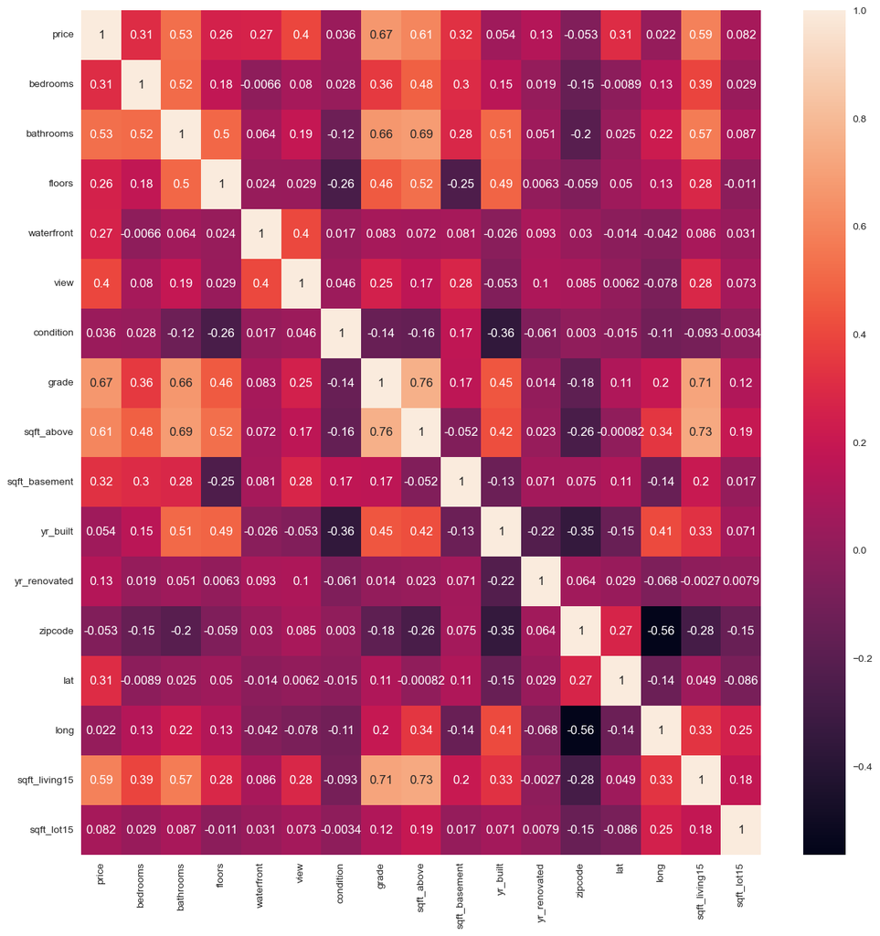

```python
import matplotlib.pyplot as plt
fig, ax = plt.subplots(figsize=(15,15))
ax = sns.heatmap(dataset.corr(), annot=True)
```

```python
dataset.head()
```

|  | price | bedrooms | bathrooms | floors | waterfront | view | condition | grade | sqft_above | sqft_basement | yr_built | yr_renovated | zipcode | lat | long | sqft_living15 | sqft_lot15 |
| --- | --- | --- | --- | --- | --- | --- | --- | --- | --- | --- | --- | --- | --- | --- | --- | --- | --- |
| 0 | 221900.0 | 3 | 1.00 | 1.0 | 0 | 0 | 3 | 7 | 1180 | 0 | 1955 | 0 | 98178 | 47.5112 | -122.257 | 1340 | 5650 |
| 1 | 538000.0 | 3 | 2.25 | 2.0 | 0 | 0 | 3 | 7 | 2170 | 400 | 1951 | 1991 | 98125 | 47.7210 | -122.319 | 1690 | 7639 |
| 2 | 180000.0 | 2 | 1.00 | 1.0 | 0 | 0 | 3 | 6 | 770 | 0 | 1933 | 0 | 98028 | 47.7379 | -122.233 | 2720 | 8062 |
| 3 | 604000.0 | 4 | 3.00 | 1.0 | 0 | 0 | 5 | 7 | 1050 | 910 | 1965 | 0 | 98136 | 47.5208 | -122.393 | 1360 | 5000 |
| 4 | 510000.0 | 3 | 2.00 | 1.0 | 0 | 0 | 3 | 8 | 1680 | 0 | 1987 | 0 | 98074 | 47.6168 | -122.045 | 1800 | 7503 |

```python
X = dataset.iloc[:, [2, 3, 9, 10]].values
X
```

```
array([[1.000e+00, 1.000e+00, 0.000e+00, 1.955e+03],
       [2.250e+00, 2.000e+00, 4.000e+02, 1.951e+03],
       [1.000e+00, 1.000e+00, 0.000e+00, 1.933e+03],
       ...,
       [7.500e-01, 2.000e+00, 0.000e+00, 2.009e+03],
       [2.500e+00, 2.000e+00, 0.000e+00, 2.004e+03],
       [7.500e-01, 2.000e+00, 0.000e+00, 2.008e+03]])
```

```python
y = dataset.iloc[:, 0].values
y
```

```
array([221900., 538000., 180000., ..., 402101., 400000., 325000.])
```

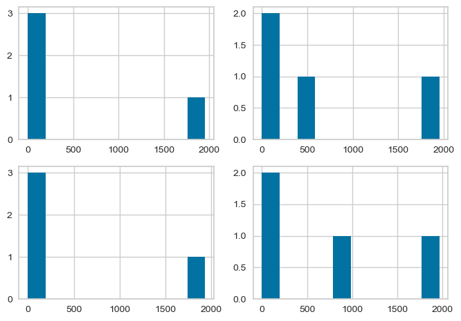

```python
import matplotlib.pyplot as plt
f, ax = plt.subplots(2, 2)
ax[0, 0].hist(X[0])
ax[0, 1].hist(X[1])
ax[1, 0].hist(X[2])
ax[1, 1].hist(X[3]);
```

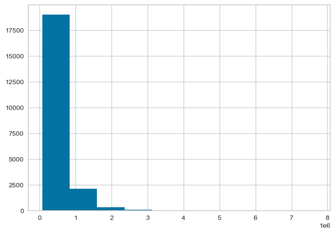

```python
plt.hist(y);
```

```python
y = np.log(y)
```

```python
from sklearn.model_selection import train_test_split
X_treinamento, X_teste, y_treinamento, y_teste = train_test_split(X, y, test_size = 0.2, random_state = 1)
X_treinamento.shape, X_teste.shape
```

```
((17290, 4), (4323, 4))
```

```python
from sklearn.linear_model import LinearRegression
regressor = LinearRegression()
regressor.fit(X_treinamento, y_treinamento)
```

```
LinearRegression()
```

```python
regressor.score(X_treinamento, y_treinamento)
```

```
0.39251171573180055
```

```python
regressor.score(X_teste, y_teste)
```

```
0.40499793112079285
```

```python
previsoes = regressor.predict(X_teste)
mean_absolute_error(y_teste, previsoes)
```

```
0.33079826724270267
```

### Usando mais atributos

```python
dataset.drop(labels = ['sqft_living15', 'sqft_lot15'], axis = 1, inplace=True)
dataset.head()
```

|  | price | bedrooms | bathrooms | floors | waterfront | view | condition | grade | sqft_above | sqft_basement | yr_built | yr_renovated | zipcode | lat | long |
| --- | --- | --- | --- | --- | --- | --- | --- | --- | --- | --- | --- | --- | --- | --- | --- |
| 0 | 221900.0 | 3 | 1.00 | 1.0 | 0 | 0 | 3 | 7 | 1180 | 0 | 1955 | 0 | 98178 | 47.5112 | -122.257 |
| 1 | 538000.0 | 3 | 2.25 | 2.0 | 0 | 0 | 3 | 7 | 2170 | 400 | 1951 | 1991 | 98125 | 47.7210 | -122.319 |
| 2 | 180000.0 | 2 | 1.00 | 1.0 | 0 | 0 | 3 | 6 | 770 | 0 | 1933 | 0 | 98028 | 47.7379 | -122.233 |
| 3 | 604000.0 | 4 | 3.00 | 1.0 | 0 | 0 | 5 | 7 | 1050 | 910 | 1965 | 0 | 98136 | 47.5208 | -122.393 |
| 4 | 510000.0 | 3 | 2.00 | 1.0 | 0 | 0 | 3 | 8 | 1680 | 0 | 1987 | 0 | 98074 | 47.6168 | -122.045 |

```python
X = dataset.iloc[:, 1:17].values
y = dataset.iloc[:, 0].values
```

```python
from sklearn.model_selection import train_test_split
from sklearn.linear_model import LinearRegression
X_treinamento, X_teste, y_treinamento, y_teste = train_test_split(X, y, test_size = 0.2, random_state = 1)
regressor = LinearRegression()
regressor.fit(X_treinamento, y_treinamento)
```

```
LinearRegression()
```

```python
regressor.score(X_treinamento, y_treinamento)
```

```
0.702834382022565
```

```python
regressor.score(X_teste, y_teste)
```

```
0.6849149549924545
```

### Selecao de atributos

A base de dados precos das casas possuem vários atributos que podem ser utilizados. A seleção de atributos é baseado em f_regression, chi2 (teste quiquadrado)

```python
dataset
```

|  | price | bedrooms | bathrooms | floors | waterfront | view | condition | grade | sqft_above | sqft_basement | yr_built | yr_renovated | zipcode | lat | long |
| --- | --- | --- | --- | --- | --- | --- | --- | --- | --- | --- | --- | --- | --- | --- | --- |
| 0 | 221900.0 | 3 | 1.00 | 1.0 | 0 | 0 | 3 | 7 | 1180 | 0 | 1955 | 0 | 98178 | 47.5112 | -122.257 |
| 1 | 538000.0 | 3 | 2.25 | 2.0 | 0 | 0 | 3 | 7 | 2170 | 400 | 1951 | 1991 | 98125 | 47.7210 | -122.319 |
| 2 | 180000.0 | 2 | 1.00 | 1.0 | 0 | 0 | 3 | 6 | 770 | 0 | 1933 | 0 | 98028 | 47.7379 | -122.233 |
| 3 | 604000.0 | 4 | 3.00 | 1.0 | 0 | 0 | 5 | 7 | 1050 | 910 | 1965 | 0 | 98136 | 47.5208 | -122.393 |
| 4 | 510000.0 | 3 | 2.00 | 1.0 | 0 | 0 | 3 | 8 | 1680 | 0 | 1987 | 0 | 98074 | 47.6168 | -122.045 |
| ... | ... | ... | ... | ... | ... | ... | ... | ... | ... | ... | ... | ... | ... | ... | ... |
| 21608 | 360000.0 | 3 | 2.50 | 3.0 | 0 | 0 | 3 | 8 | 1530 | 0 | 2009 | 0 | 98103 | 47.6993 | -122.346 |
| 21609 | 400000.0 | 4 | 2.50 | 2.0 | 0 | 0 | 3 | 8 | 2310 | 0 | 2014 | 0 | 98146 | 47.5107 | -122.362 |
| 21610 | 402101.0 | 2 | 0.75 | 2.0 | 0 | 0 | 3 | 7 | 1020 | 0 | 2009 | 0 | 98144 | 47.5944 | -122.299 |
| 21611 | 400000.0 | 3 | 2.50 | 2.0 | 0 | 0 | 3 | 8 | 1600 | 0 | 2004 | 0 | 98027 | 47.5345 | -122.069 |
| 21612 | 325000.0 | 2 | 0.75 | 2.0 | 0 | 0 | 3 | 7 | 1020 | 0 | 2008 | 0 | 98144 | 47.5941 | -122.299 |

21613 rows × 15 columns

```python
from sklearn.feature_selection import SelectFdr, f_regression
selecao = SelectFdr(f_regression, alpha = 0.0)
X_novo = selecao.fit_transform(X, y)
X.shape, X_novo.shape
```

```
((21613, 14), (21613, 8))
```

```python
selecao.pvalues_
```

```
array([0.00000000e+000, 0.00000000e+000, 1.58101007e-322, 0.00000000e+000,
       0.00000000e+000, 8.93565406e-008, 0.00000000e+000, 0.00000000e+000,
       0.00000000e+000, 1.92987281e-015, 1.02134789e-077, 5.01105043e-015,
       0.00000000e+000, 1.47509222e-003])
```

```python
colunas = selecao.get_support()
colunas
```

```
array([ True,  True, False,  True,  True, False,  True,  True,  True,
       False, False, False,  True, False])
```

```python
dataset.columns[1:17]
```

```
Index(['bedrooms', 'bathrooms', 'floors', 'waterfront', 'view', 'condition',
       'grade', 'sqft_above', 'sqft_basement', 'yr_built', 'yr_renovated',
       'zipcode', 'lat', 'long'],
      dtype='object')
```

```python
dataset.columns[1:17][colunas == True]
```

```
Index(['bedrooms', 'bathrooms', 'waterfront', 'view', 'grade', 'sqft_above',
       'sqft_basement', 'lat'],
      dtype='object')
```

```python
from sklearn.model_selection import train_test_split
from sklearn.linear_model import LinearRegression
X_treinamento, X_teste, y_treinamento, y_teste = train_test_split(X_novo, y, test_size = 0.2, random_state = 1)
regressor = LinearRegression()
regressor.fit(X_treinamento, y_treinamento)
```

```
LinearRegression()
```

```python
regressor.score(X_treinamento, y_treinamento)
```

```
0.6600844333469127
```

```python
regressor.score(X_teste, y_teste)
```

```
0.6443733684297973
```

## Regressão Polinomial

A ideia é ao invés de traçar uma reta que melhor representa nosso conjunto de dados, será feita uma curva.

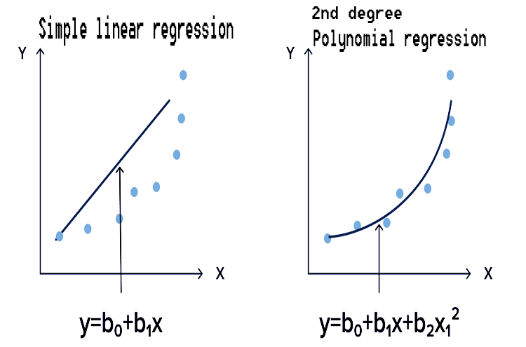

para cada característica xi, temos que aplicar ao grao do polinômio escolhido

### Base plano de saúde

```python
import pandas as pd
from sklearn.linear_model import LinearRegression
from sklearn.preprocessing import PolynomialFeatures
import plotly.express as px
```

```python
df_plano_saude=pd.read_csv('data_base/plano_saude2.csv')
df_plano_saude.head()
```

|  | idade | custo |
| --- | --- | --- |
| 0 | 18 | 470 |
| 1 | 23 | 520 |
| 2 | 28 | 630 |
| 3 | 33 | 830 |
| 4 | 38 | 1150 |

```python
x_plano_saude = df_plano_saude.iloc[:, 0:1].values
y_plano_saude = df_plano_saude.iloc[:, 1:2].values
```

```python
display(x_plano_saude)
display(y_plano_saude)
```

```
array([[18],
       [23],
       [28],
       [33],
       [38],
       [43],
       [48],
       [53],
       [58],
       [63]], dtype=int64)
```

```
array([[  470],
       [  520],
       [  630],
       [  830],
       [ 1150],
       [ 1530],
       [ 2040],
       [ 3080],
       [ 5100],
       [10100]], dtype=int64)
```

```python
x_plano_saude.shape, y_plano_saude.shape
```

```
((10, 1), (10, 1))
```

```python
y_plano_saude = y_plano_saude.reshape(-1, 1) #adiciona uma dimensao de coluna
display(y_plano_saude.shape)
display(y_plano_saude)
```

```
(10, 1)
```

```
array([[  470],
       [  520],
       [  630],
       [  830],
       [ 1150],
       [ 1530],
       [ 2040],
       [ 3080],
       [ 5100],
       [10100]], dtype=int64)
```

```python
poly= PolynomialFeatures(degree=4) # grau do polinomio
x_poly=poly.fit_transform(x_plano_saude) # transforma os dados em polinomio
display(x_poly.shape) # mostra o tamanho do polinomio
display(x_poly) # mostra o polinomio
```

```
(10, 5)
```

```
array([[1.0000000e+00, 1.8000000e+01, 3.2400000e+02, 5.8320000e+03,
        1.0497600e+05],
       [1.0000000e+00, 2.3000000e+01, 5.2900000e+02, 1.2167000e+04,
        2.7984100e+05],
       [1.0000000e+00, 2.8000000e+01, 7.8400000e+02, 2.1952000e+04,
        6.1465600e+05],
       [1.0000000e+00, 3.3000000e+01, 1.0890000e+03, 3.5937000e+04,
        1.1859210e+06],
       [1.0000000e+00, 3.8000000e+01, 1.4440000e+03, 5.4872000e+04,
        2.0851360e+06],
       [1.0000000e+00, 4.3000000e+01, 1.8490000e+03, 7.9507000e+04,
        3.4188010e+06],
       [1.0000000e+00, 4.8000000e+01, 2.3040000e+03, 1.1059200e+05,
        5.3084160e+06],
       [1.0000000e+00, 5.3000000e+01, 2.8090000e+03, 1.4887700e+05,
        7.8904810e+06],
       [1.0000000e+00, 5.8000000e+01, 3.3640000e+03, 1.9511200e+05,
        1.1316496e+07],
       [1.0000000e+00, 6.3000000e+01, 3.9690000e+03, 2.5004700e+05,
        1.5752961e+07]])
```

```python
display(x_plano_saude[0])
display(x_poly[0]) # mostra o polinomio do primeiro dado
# o polinomio do primeiro dado é [1, 1, 1,1,1] ou seja, 1*x^0 + 1*x^1 + 1*x^2 +
# Logo o x é substituido por 18 e aplicado a cada um desses valores.
```

```
array([18], dtype=int64)
```

```
array([1.00000e+00, 1.80000e+01, 3.24000e+02, 5.83200e+03, 1.04976e+05])
```

```python
regressor_polinomial = LinearRegression() # cria o modelo de regressao
regressor_polinomial.fit(x_poly, y_plano_saude) # faz o ajuste do modelo com os dados de treino
```

```
LinearRegression()
```

A baixo temos b0*x1 + b1*x1 + b2*x1 + b3*x1 + b4*x1 o intercepto é b0 e os demais coeficientes o b1..bn

```python
display(regressor_polinomial.intercept_) # mostra o valor do intercepto b0
display(regressor_polinomial.coef_) # mostra os coeficientes b1, b2, b3, ... , bn
```

```
array([16561.97465354])
```

```
array([[ 0.00000000e+00, -2.12242253e+03,  9.90404200e+01,
        -1.95058276e+00,  1.40792541e-02]])
```

```python
novo=[[40]] # novo dado para prever o valor do plano de saude, simulando uma idade
novo=poly.transform(novo) # transforma o novo dado em polinomio
display(novo) # mostra o polinomio do novo dado
display(novo.shape) # mostra o tamanho do polinomio do novo dado
```

```
array([[1.00e+00, 4.00e+01, 1.60e+03, 6.40e+04, 2.56e+06]])
```

```
(1, 5)
```

[output not shown]

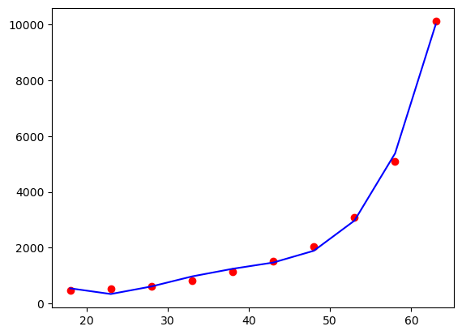

```python
display(regressor_polinomial.predict(novo)) # faz a previsao do novo dado
import matplotlib.pyplot as plt
plt.scatter(x_plano_saude, y_plano_saude, color='red') # plota os dados de treino
plt.plot(x_plano_saude, regressor_polinomial.predict(poly.fit_transform(x_plano_saude)), color='blue') # plota a linha de regressao
```

[output not shown]

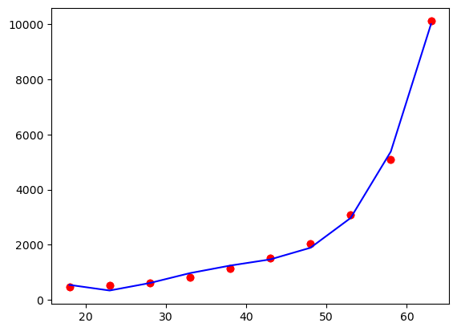

```python
previsoes= regressor_polinomial.predict(x_poly) # faz a previsao dos dados de treino
display(previsoes) # mostra as previsoes dos dados de treino
plt.scatter(x_plano_saude, y_plano_saude, color='red') # plota os dados de treino
plt.plot(x_plano_saude, previsoes, color='blue') # plota a linha de regressao
plt.scatter(x_plano_saude, y_plano_saude, color='red') # plota os dados de treino
```

```python
x_plano_saude.shape, y_plano_saude.shape # mostra o tamanho dos dados de treino
```

```
((10, 1), (10, 1))
```

```python
x_plano_saude[:,0].ravel().shape # ravel transforma o array em uma linha
```

```
(10,)
```

ravel serve para transformar a matriz [10,1] e um vetor

```python
grafico=px.scatter(x=x_plano_saude[:,0].ravel(), y=y_plano_saude.ravel() ) # plota os dados de treino em 3D
grafico.add_scatter(x=x_plano_saude[:,0].ravel(), y=previsoes.ravel(), mode='lines', name='Previsao') # plota a linha de regressao em 3D
grafico.show() # mostra o grafico em 3D
```

[output not shown]

### Base preço de casas

```python
from sklearn.model_selection import train_test_split
dataset = pd.read_csv('data_base/house_prices.csv')
dataset.head()
```

|  | id | date | price | bedrooms | bathrooms | sqft_living | sqft_lot | floors | waterfront | view | ... | grade | sqft_above | sqft_basement | yr_built | yr_renovated | zipcode | lat | long | sqft_living15 | sqft_lot15 |
| --- | --- | --- | --- | --- | --- | --- | --- | --- | --- | --- | --- | --- | --- | --- | --- | --- | --- | --- | --- | --- | --- |
| 0 | 7129300520 | 20141013T000000 | 221900.0 | 3 | 1.00 | 1180 | 5650 | 1.0 | 0 | 0 | ... | 7 | 1180 | 0 | 1955 | 0 | 98178 | 47.5112 | -122.257 | 1340 | 5650 |
| 1 | 6414100192 | 20141209T000000 | 538000.0 | 3 | 2.25 | 2570 | 7242 | 2.0 | 0 | 0 | ... | 7 | 2170 | 400 | 1951 | 1991 | 98125 | 47.7210 | -122.319 | 1690 | 7639 |
| 2 | 5631500400 | 20150225T000000 | 180000.0 | 2 | 1.00 | 770 | 10000 | 1.0 | 0 | 0 | ... | 6 | 770 | 0 | 1933 | 0 | 98028 | 47.7379 | -122.233 | 2720 | 8062 |
| 3 | 2487200875 | 20141209T000000 | 604000.0 | 4 | 3.00 | 1960 | 5000 | 1.0 | 0 | 0 | ... | 7 | 1050 | 910 | 1965 | 0 | 98136 | 47.5208 | -122.393 | 1360 | 5000 |
| 4 | 1954400510 | 20150218T000000 | 510000.0 | 3 | 2.00 | 1680 | 8080 | 1.0 | 0 | 0 | ... | 8 | 1680 | 0 | 1987 | 0 | 98074 | 47.6168 | -122.045 | 1800 | 7503 |

5 rows × 21 columns

```python
dataset.columns
```

```
Index(['id', 'date', 'price', 'bedrooms', 'bathrooms', 'sqft_living',
       'sqft_lot', 'floors', 'waterfront', 'view', 'condition', 'grade',
       'sqft_above', 'sqft_basement', 'yr_built', 'yr_renovated', 'zipcode',
       'lat', 'long', 'sqft_living15', 'sqft_lot15'],
      dtype='object')
```

```python
X= dataset.iloc[:, [3,4,5,6,7,9,10,11,12,13,14,15]].values # seleciona as colunas que serao usadas como variaveis independentes
display(X)
y=dataset.iloc[:,2].values # seleciona a coluna que sera usada como variavel dependente
display(y)
```

```
array([[3.000e+00, 1.000e+00, 1.180e+03, ..., 0.000e+00, 1.955e+03,
        0.000e+00],
       [3.000e+00, 2.250e+00, 2.570e+03, ..., 4.000e+02, 1.951e+03,
        1.991e+03],
       [2.000e+00, 1.000e+00, 7.700e+02, ..., 0.000e+00, 1.933e+03,
        0.000e+00],
       ...,
       [2.000e+00, 7.500e-01, 1.020e+03, ..., 0.000e+00, 2.009e+03,
        0.000e+00],
       [3.000e+00, 2.500e+00, 1.600e+03, ..., 0.000e+00, 2.004e+03,
        0.000e+00],
       [2.000e+00, 7.500e-01, 1.020e+03, ..., 0.000e+00, 2.008e+03,
        0.000e+00]])
```

```
array([221900., 538000., 180000., ..., 402101., 400000., 325000.])
```

```python
X_casas_treinamento, X_casas_teste, y_casas_treinamento, y_casas_teste = train_test_split(X, y, test_size = 0.3, random_state = 0)
```

```python
from sklearn.feature_selection import SelectFdr, f_regression
selecao = SelectFdr(f_regression, alpha = 0.0)
X_novo = selecao.fit_transform(X_casas_treinamento, y_casas_treinamento)
X.shape, X_novo.shape
```

```
((21613, 12), (15129, 7))
```

```python
colunas = selecao.get_support()
display(colunas)
X_novo=X_novo[:,:] # seleciona as colunas que foram escolhidas pelo algoritmo de selecao de atributos
X_novo.shape # mostra o tamanho dos dados de treino
```

```
array([ True,  True,  True, False, False,  True, False,  True,  True,
        True, False, False])
```

```
(15129, 7)
```

```python
poly= PolynomialFeatures(degree=4) # grau do polinomio
x_poly2=poly.fit_transform(X_novo) # transforma os dados em polinomio
display(x_poly2.shape) # mostra o tamanho do polinomio
display(x_poly2) # mostra o polinomio
```

```
(15129, 330)
```

```
array([[1.00000000e+00, 4.00000000e+00, 1.50000000e+00, ...,
        8.12250000e+10, 1.78125000e+10, 3.90625000e+09],
       [1.00000000e+00, 3.00000000e+00, 1.50000000e+00, ...,
        0.00000000e+00, 0.00000000e+00, 0.00000000e+00],
       [1.00000000e+00, 5.00000000e+00, 2.75000000e+00, ...,
        0.00000000e+00, 0.00000000e+00, 0.00000000e+00],
       ...,
       [1.00000000e+00, 3.00000000e+00, 2.25000000e+00, ...,
        0.00000000e+00, 0.00000000e+00, 0.00000000e+00],
       [1.00000000e+00, 4.00000000e+00, 2.00000000e+00, ...,
        0.00000000e+00, 0.00000000e+00, 0.00000000e+00],
       [1.00000000e+00, 4.00000000e+00, 2.25000000e+00, ...,
        1.67340096e+12, 9.12764160e+11, 4.97871360e+11]])
```

```python
x_poly2_teste=poly.fit_transform(X_casas_teste[:,colunas]) # transforma os dados de teste em polinomio
display(x_poly2_teste.shape) # mostra o tamanho do polinomio de teste
```

```
(6484, 330)
```

#### Explicacao numero de termos resultantes

Em tese temos 7 atributos, logo 7 atributos irão ter o valor da constante (intercepto)

para grau 1: temos 7 atributos para grau 1

para grau 2: temos 7 atributos para grau 2

logo daria 21, porém não é assim que é considerado, pois acontece uma interação:

Termos de Interação: O produto de cada par distinto de atributos originais.  
Atributos: x₁x₂, x₁x₃, ..., x₁x₇ (6 termos)  
x₂x₃, x₂x₄, ..., x₂x₇ (5 termos)  
x₃x₄, ..., x₃x₇ (4 termos)  
x₄x₅, x₄x₆, x₄x₇ (3 termos)  
x₅x₆, x₅x₇ (2 termos)  
x₆x₇ (1 termo)  
Número total de termos de interação: 6 + 5 + 4 + 3 + 2 + 1 = 21 termos.  
Alternativamente, isso é o número de combinações de 7 atributos tomados 2 a 2: C(7, 2) = 7! / (2! * (7-2)!) = (7 * 6) / 2 = 21.

```python
x_poly2[0]
```

```
array([1.00000000e+00, 4.00000000e+00, 1.50000000e+00, 1.39000000e+03,
       0.00000000e+00, 7.00000000e+00, 1.14000000e+03, 2.50000000e+02,
       1.60000000e+01, 6.00000000e+00, 5.56000000e+03, 0.00000000e+00,
       2.80000000e+01, 4.56000000e+03, 1.00000000e+03, 2.25000000e+00,
       2.08500000e+03, 0.00000000e+00, 1.05000000e+01, 1.71000000e+03,
       3.75000000e+02, 1.93210000e+06, 0.00000000e+00, 9.73000000e+03,
       1.58460000e+06, 3.47500000e+05, 0.00000000e+00, 0.00000000e+00,
       0.00000000e+00, 0.00000000e+00, 4.90000000e+01, 7.98000000e+03,
       1.75000000e+03, 1.29960000e+06, 2.85000000e+05, 6.25000000e+04,
       6.40000000e+01, 2.40000000e+01, 2.22400000e+04, 0.00000000e+00,
       1.12000000e+02, 1.82400000e+04, 4.00000000e+03, 9.00000000e+00,
       8.34000000e+03, 0.00000000e+00, 4.20000000e+01, 6.84000000e+03,
       1.50000000e+03, 7.72840000e+06, 0.00000000e+00, 3.89200000e+04,
       6.33840000e+06, 1.39000000e+06, 0.00000000e+00, 0.00000000e+00,
       0.00000000e+00, 0.00000000e+00, 1.96000000e+02, 3.19200000e+04,
       7.00000000e+03, 5.19840000e+06, 1.14000000e+06, 2.50000000e+05,
       3.37500000e+00, 3.12750000e+03, 0.00000000e+00, 1.57500000e+01,
       2.56500000e+03, 5.62500000e+02, 2.89815000e+06, 0.00000000e+00,
       1.45950000e+04, 2.37690000e+06, 5.21250000e+05, 0.00000000e+00,
       0.00000000e+00, 0.00000000e+00, 0.00000000e+00, 7.35000000e+01,
       1.19700000e+04, 2.62500000e+03, 1.94940000e+06, 4.27500000e+05,
       9.37500000e+04, 2.68561900e+09, 0.00000000e+00, 1.35247000e+07,
       2.20259400e+09, 4.83025000e+08, 0.00000000e+00, 0.00000000e+00,
       0.00000000e+00, 0.00000000e+00, 6.81100000e+04, 1.10922000e+07,
       2.43250000e+06, 1.80644400e+09, 3.96150000e+08, 8.68750000e+07,
       0.00000000e+00, 0.00000000e+00, 0.00000000e+00, 0.00000000e+00,
       0.00000000e+00, 0.00000000e+00, 0.00000000e+00, 0.00000000e+00,
       0.00000000e+00, 0.00000000e+00, 3.43000000e+02, 5.58600000e+04,
       1.22500000e+04, 9.09720000e+06, 1.99500000e+06, 4.37500000e+05,
       1.48154400e+09, 3.24900000e+08, 7.12500000e+07, 1.56250000e+07,
       2.56000000e+02, 9.60000000e+01, 8.89600000e+04, 0.00000000e+00,
       4.48000000e+02, 7.29600000e+04, 1.60000000e+04, 3.60000000e+01,
       3.33600000e+04, 0.00000000e+00, 1.68000000e+02, 2.73600000e+04,
       6.00000000e+03, 3.09136000e+07, 0.00000000e+00, 1.55680000e+05,
       2.53536000e+07, 5.56000000e+06, 0.00000000e+00, 0.00000000e+00,
       0.00000000e+00, 0.00000000e+00, 7.84000000e+02, 1.27680000e+05,
       2.80000000e+04, 2.07936000e+07, 4.56000000e+06, 1.00000000e+06,
       1.35000000e+01, 1.25100000e+04, 0.00000000e+00, 6.30000000e+01,
       1.02600000e+04, 2.25000000e+03, 1.15926000e+07, 0.00000000e+00,
       5.83800000e+04, 9.50760000e+06, 2.08500000e+06, 0.00000000e+00,
```

[output cut: 28 more lines]

```
       2.51095716e+12, 5.50648500e+11, 1.20756250e+11, 0.00000000e+00,
       0.00000000e+00, 0.00000000e+00, 0.00000000e+00, 0.00000000e+00,
       0.00000000e+00, 0.00000000e+00, 0.00000000e+00, 0.00000000e+00,
       0.00000000e+00, 4.76770000e+05, 7.76454000e+07, 1.70275000e+07,
       1.26451080e+10, 2.77305000e+09, 6.08125000e+08, 2.05934616e+12,
       4.51611000e+11, 9.90375000e+10, 2.17187500e+10, 0.00000000e+00,
       0.00000000e+00, 0.00000000e+00, 0.00000000e+00, 0.00000000e+00,
       0.00000000e+00, 0.00000000e+00, 0.00000000e+00, 0.00000000e+00,
       0.00000000e+00, 0.00000000e+00, 0.00000000e+00, 0.00000000e+00,
       0.00000000e+00, 0.00000000e+00, 0.00000000e+00, 0.00000000e+00,
       0.00000000e+00, 0.00000000e+00, 0.00000000e+00, 2.40100000e+03,
       3.91020000e+05, 8.57500000e+04, 6.36804000e+07, 1.39650000e+07,
       3.06250000e+06, 1.03708080e+10, 2.27430000e+09, 4.98750000e+08,
       1.09375000e+08, 1.68896016e+12, 3.70386000e+11, 8.12250000e+10,
       1.78125000e+10, 3.90625000e+09])
```

```python
regressor_polinomial = LinearRegression() # cria o modelo de regressao
regressor_polinomial.fit(x_poly2, y_casas_treinamento) # faz o ajuste do modelo com os dados de treino
```

```
LinearRegression()
```

```python
display(regressor_polinomial.score(x_poly2, y_casas_treinamento)) # mostra o score do modelo de regressao polinomial dados de treinamento
display(regressor_polinomial.score(x_poly2_teste, y_casas_teste)) # mostra o score do modelo de regressao polinomial dados de teste
```

```
0.6556043112452767
```

```
0.5075796064285562
```

## Regressão por Árvore de Decisão

A regressão na árvore de decisão consiste em realizar split (cria um ponto de ramificação da árvore) que separada atributos em R^n , com x1 e x2 sendo atributos e y o resultado:

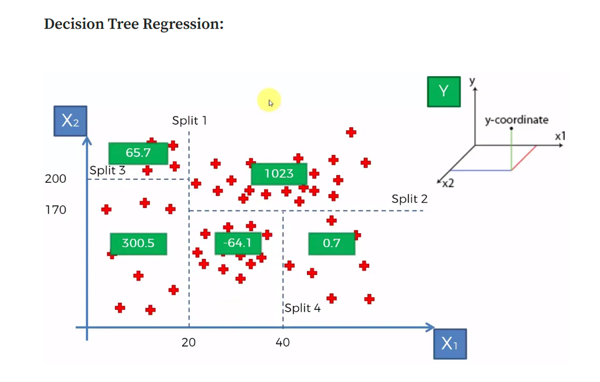